# income_data_analysis (1)

## Mariusz Mańka, Michał Hutnik

## Informatyka - niestajconarnie - V semestr

## Wydział Matematyki Stosowanej

## Przedmiot: Języki Skryptowe w Analizie Danych

# Analiza przychodów wraz ze szczególnym rozróżnieniem czy dana osoba zarabia więcej niż 50 000 USD rocznie oraz do jakich grup społecznych należy.

Dane w formacie CSV, użyte w tej analizie pochodzą ze strony: https://www.kaggle.com/uciml/adult-census-income  
oraz badają czy dana osoba zarabia powyżej 50 000 USD rocznie oraz jakie spełnia przy tym warunki.

## Cel analizy:

Celem naszej analizy jest ustalenie do jakich grup należą oraz jakie warunki najczęściej spełniają osoby zarabiajace powyżej 50 000 rocznie. Chcemy ustalić przybliżony profil takiej osoby.

### Opis kolumn:

- **age** - `int64` - Wiek badanej osoby
- **workclass** - `string`- Forma zatrudnienia badanej osoby
- **fnlwgt** - `int64` - Szacowana liczba osób, które reprezentuje każdy wiersz danych (liczba osób o podobnym zestawie cech)
- **education** - `string` - Zdobyte wykształcenie
- **educational-num** - `int64` - Lata nauki
- **marital-status** - `string` - Stan cywilny
- **occupation** - `string` - Zawód wykonywany przez badaną osobę
- **relationship** - `string` - Relacje rodzinne badanej osoby
- **race** - `string` - Rasa
- **gender** - `string` - Płeć
- **capital-gain** - `int64` - Zysk kapitałowy
- **capital-loss** - `int64` - Strata kapitału
- **hours-per-week** - `int64` - Godziny pracy w tygodniu
- **native-country** - `string` - Kraj ojczysty
- **income_>50K** - `int64` - Informacja czy badana osoba osiągnęła zysk powyżej 50 000.

# Import oraz odczyt danych

```python
#Income dataset
import pandas as pd
import seaborn as sns
import matplotlib.pyplot as plt
import numpy as np
import re
```

### Pobieramy dane do dalszej obróbki wskazując że dane oddzielone są przecinkiem

```python
CSV_DATA_URL = "https://community052.blob.core.windows.net/csvs/train.csv"
df_income = pd.read_csv(CSV_DATA_URL, delimiter=',')
```

### Przykładowa struktura bazy danych w postaci tabeli (pierwsze 40 rekordów)

```python
df_income.head(40)
```

|  | age | workclass | fnlwgt | education | educational-num | marital-status | occupation | relationship | race | gender | capital-gain | capital-loss | hours-per-week | native-country | income_>50K |
| --- | --- | --- | --- | --- | --- | --- | --- | --- | --- | --- | --- | --- | --- | --- | --- |
| 0 | 67 | Private | 366425 | Doctorate | 16 | Divorced | Exec-managerial | Not-in-family | White | Male | 99999 | 0 | 60 | United-States | 1 |
| 1 | 17 | Private | 244602 | 12th | 8 | Never-married | Other-service | Own-child | White | Male | 0 | 0 | 15 | United-States | 0 |
| 2 | 31 | Private | 174201 | Bachelors | 13 | Married-civ-spouse | Exec-managerial | Husband | White | Male | 0 | 0 | 40 | United-States | 1 |
| 3 | 58 | State-gov | 110199 | 7th-8th | 4 | Married-civ-spouse | Transport-moving | Husband | White | Male | 0 | 0 | 40 | United-States | 0 |
| 4 | 25 | State-gov | 149248 | Some-college | 10 | Never-married | Other-service | Not-in-family | Black | Male | 0 | 0 | 40 | United-States | 0 |
| 5 | 59 | State-gov | 105363 | HS-grad | 9 | Never-married | Adm-clerical | Own-child | White | Male | 0 | 0 | 40 | United-States | 0 |
| 6 | 70 | Private | 216390 | 9th | 5 | Married-civ-spouse | Machine-op-inspct | Wife | White | Female | 2653 | 0 | 40 | United-States | 0 |
| 7 | 35 | Self-emp-not-inc | 361888 | Bachelors | 13 | Married-civ-spouse | Sales | Husband | White | Male | 0 | 0 | 60 | Japan | 0 |
| 8 | 28 | Private | 74784 | HS-grad | 9 | Never-married | Handlers-cleaners | Not-in-family | White | Male | 0 | 0 | 50 | United-States | 0 |
| 9 | 28 | Private | 118089 | HS-grad | 9 | Married-civ-spouse | Exec-managerial | Husband | White | Male | 4386 | 0 | 45 | United-States | 1 |
| 10 | 21 | Private | 138513 | Some-college | 10 | Never-married | Exec-managerial | Own-child | White | Male | 0 | 0 | 25 | United-States | 0 |
| 11 | 30 | Self-emp-not-inc | 100252 | HS-grad | 9 | Married-civ-spouse | Machine-op-inspct | Own-child | Asian-Pac-Islander | Male | 0 | 0 | 60 | South | 0 |
| 12 | 59 | Self-emp-not-inc | 241297 | Some-college | 10 | Widowed | Farming-fishing | Not-in-family | White | Female | 6849 | 0 | 40 | United-States | 0 |
| 13 | 20 | Private | 39764 | HS-grad | 9 | Never-married | Handlers-cleaners | Own-child | White | Male | 0 | 0 | 40 | United-States | 0 |
| 14 | 45 | Private | 30690 | 7th-8th | 4 | Never-married | Other-service | Not-in-family | White | Male | 0 | 0 | 10 | United-States | 0 |
| 15 | 76 | Private | 316185 | 7th-8th | 4 | Widowed | Protective-serv | Not-in-family | White | Female | 0 | 0 | 12 | United-States | 0 |
| 16 | 30 | Private | 110239 | 10th | 6 | Married-civ-spouse | Transport-moving | Husband | White | Male | 0 | 0 | 55 | United-States | 0 |
| 17 | 54 | Federal-gov | 278076 | HS-grad | 9 | Married-civ-spouse | Exec-managerial | Husband | White | Male | 5178 | 0 | 40 | United-States | 1 |
| 18 | 19 | Local-gov | 259169 | Some-college | 10 | Never-married | Prof-specialty | Own-child | White | Female | 0 | 0 | 30 | United-States | 0 |
| 19 | 44 | Private | 136986 | Doctorate | 16 | Married-civ-spouse | Prof-specialty | Husband | White | Male | 0 | 0 | 50 | United-States | 1 |
| 20 | 31 | Private | 154227 | Some-college | 10 | Married-civ-spouse | Transport-moving | Husband | White | Male | 0 | 0 | 40 | United-States | 0 |
| 21 | 47 | Private | 117774 | HS-grad | 9 | Married-civ-spouse | Sales | Husband | White | Male | 0 | 0 | 40 | Portugal | 0 |
| 22 | 37 | Self-emp-not-inc | 174308 | HS-grad | 9 | Married-civ-spouse | Craft-repair | Husband | White | Male | 0 | 0 | 40 | United-States | 0 |
| 23 | 59 | Private | 189721 | Bachelors | 13 | Married-civ-spouse | Handlers-cleaners | Husband | White | Male | 0 | 0 | 40 | Italy | 1 |
| 24 | 27 | Self-emp-not-inc | 229125 | 11th | 7 | Married-civ-spouse | Craft-repair | Husband | White | Male | 0 | 0 | 40 | United-States | 0 |
| 25 | 24 | Private | 341294 | HS-grad | 9 | Married-civ-spouse | Machine-op-inspct | Husband | White | Male | 0 | 0 | 40 | United-States | 0 |
| 26 | 49 | Private | 102583 | Some-college | 10 | Married-civ-spouse | Prof-specialty | Husband | White | Male | 0 | 1848 | 44 | United-States | 1 |
| 27 | 36 | Private | 64874 | Masters | 14 | Married-civ-spouse | Prof-specialty | Husband | White | Male | 0 | 0 | 60 | United-States | 1 |
| 28 | 54 | Self-emp-inc | 129432 | Bachelors | 13 | Married-civ-spouse | Exec-managerial | Husband | White | Male | 15024 | 0 | 40 | United-States | 1 |
| 29 | 44 | Private | 163331 | Some-college | 10 | Widowed | Adm-clerical | Unmarried | White | Female | 0 | 0 | 32 | United-States | 0 |
| 30 | 35 | Private | 38245 | Some-college | 10 | Married-civ-spouse | Craft-repair | Husband | White | Male | 0 | 0 | 60 | United-States | 0 |
| 31 | 19 | Local-gov | 167816 | HS-grad | 9 | Divorced | Exec-managerial | Not-in-family | White | Female | 0 | 0 | 35 | United-States | 0 |
| 32 | 71 | Private | 152307 | HS-grad | 9 | Married-civ-spouse | Exec-managerial | Husband | White | Male | 0 | 2377 | 45 | United-States | 1 |
| 33 | 20 | NaN | 249087 | Some-college | 10 | Never-married | NaN | Own-child | White | Female | 0 | 0 | 40 | United-States | 0 |
| 34 | 62 | Self-emp-not-inc | 136684 | HS-grad | 9 | Widowed | Adm-clerical | Other-relative | White | Female | 0 | 0 | 30 | United-States | 0 |
| 35 | 35 | Self-emp-not-inc | 241126 | HS-grad | 9 | Never-married | Craft-repair | Other-relative | White | Male | 0 | 0 | 60 | United-States | 0 |
| 36 | 64 | Local-gov | 287277 | 9th | 5 | Married-civ-spouse | Other-service | Husband | White | Male | 0 | 0 | 40 | United-States | 0 |
| 37 | 53 | Private | 188644 | Preschool | 1 | Married-civ-spouse | Other-service | Husband | White | Male | 0 | 0 | 40 | Mexico | 0 |
| 38 | 30 | Private | 182833 | Some-college | 10 | Never-married | Exec-managerial | Own-child | Black | Female | 0 | 0 | 40 | United-States | 0 |
| 39 | 34 | Private | 434463 | Bachelors | 13 | Never-married | Machine-op-inspct | Not-in-family | White | Female | 0 | 0 | 39 | United-States | 0 |

### Podstawowe informacje o strukturze danych:

```python
df_income.info()
```

```
<class 'pandas.core.frame.DataFrame'>
RangeIndex: 43957 entries, 0 to 43956
Data columns (total 15 columns):
 #   Column           Non-Null Count  Dtype
---  ------           --------------  -----
 0   age              43957 non-null  int64
 1   workclass        41459 non-null  object
 2   fnlwgt           43957 non-null  int64
 3   education        43957 non-null  object
 4   educational-num  43957 non-null  int64
 5   marital-status   43957 non-null  object
 6   occupation       41451 non-null  object
 7   relationship     43957 non-null  object
 8   race             43957 non-null  object
 9   gender           43957 non-null  object
 10  capital-gain     43957 non-null  int64
 11  capital-loss     43957 non-null  int64
 12  hours-per-week   43957 non-null  int64
 13  native-country   43194 non-null  object
 14  income_>50K      43957 non-null  int64
dtypes: int64(7), object(8)
memory usage: 5.0+ MB
```

### Unikalne wartości opisowe dla poszczególnych kolumn

```python
print("workclass:")
print(df_income["workclass"].unique(), end='\n\n')
print("education:")
print(df_income["education"].unique(), end='\n\n')
print("marital-status:")
print(df_income["marital-status"].unique(), end='\n\n')
print("occupation:")
print(df_income["occupation"].unique(), end='\n\n')
print("relationship:")
print(df_income["relationship"].unique(), end='\n\n')
print("race:")
print(df_income["race"].unique(), end='\n\n')
print("gender:")
print(df_income["gender"].unique(), end='\n\n')
```

```
workclass:
['Private' 'State-gov' 'Self-emp-not-inc' 'Federal-gov' 'Local-gov'
 'Self-emp-inc' nan 'Never-worked' 'Without-pay']

education:
['Doctorate' '12th' 'Bachelors' '7th-8th' 'Some-college' 'HS-grad' '9th'
 '10th' '11th' 'Masters' 'Preschool' '5th-6th' 'Prof-school' 'Assoc-voc'
 '1st-4th' 'Assoc-acdm']

marital-status:
['Divorced' 'Never-married' 'Married-civ-spouse' 'Widowed' 'Separated'
 'Married-spouse-absent' 'Married-AF-spouse']

occupation:
['Exec-managerial' 'Other-service' 'Transport-moving' 'Adm-clerical'
 'Machine-op-inspct' 'Sales' 'Handlers-cleaners' 'Farming-fishing'
 'Protective-serv' 'Prof-specialty' 'Craft-repair' nan 'Tech-support'
 'Priv-house-serv' 'Armed-Forces']

relationship:
['Not-in-family' 'Own-child' 'Husband' 'Wife' 'Unmarried' 'Other-relative']

race:
['White' 'Black' 'Asian-Pac-Islander' 'Other' 'Amer-Indian-Eskimo']

gender:
['Male' 'Female']
```

# Przygotowanie danych do dalszej pracy

```python
df_income.dtypes
```

```
age                 int64
workclass          object
fnlwgt              int64
education          object
educational-num     int64
marital-status     object
occupation         object
relationship       object
race               object
gender             object
capital-gain        int64
capital-loss        int64
hours-per-week      int64
native-country     object
income_>50K         int64
dtype: object
```

### Konwertujemy kolumnę `income_>50k` z typu int64 na typ bool. Dane w tej kolumnie zawierają wartości 1 lub 0 stąd konwersja przebiega bez problemu.

```python
df_income['income_>50K'] = df_income['income_>50K'].astype(bool)
df_income['income_>50K']
```

```
0         True
1        False
2         True
3        False
4        False
         ...
43952     True
43953    False
43954    False
43955    False
43956    False
Name: income_>50K, Length: 43957, dtype: bool
```

```python
df_income['income_>50K'].dtype
```

```
dtype('bool')
```

# Podstawowe statystyki:

```python
print('Minimalny wiek w zbiorze:')
print(df_income["age"].min(), end='\n\n')

print('Maksymalny wiek w zbiorze:')
print(df_income['age'].max(), end='\n\n')

print('Średni wiek w zbiorze:')
print(np.round(df_income['age'].mean(), 2), end='\n\n')

print('5 najczęściej wykonywanych zawodów:', end='\n')
print(df_income['occupation'].value_counts()[:5], end='\n\n')

print('Rekord posiadający największy zysk kapitałowy:')
print(df_income.loc[df_income['capital-gain'].idxmax()], end='\n\n')

print('Rekord posiadający największą stratę zysku kapitałowego:')
print(df_income.loc[df_income['capital-loss'].idxmax()], end='\n\n')

print('Osoba pracująca najwięcej tygodniowo:')
print(df_income.loc[df_income['hours-per-week'].idxmax()], end='\n\n')

print('Osoba pracująca najmniej tygodniowo:')
print(df_income.loc[df_income['hours-per-week'].idxmin()], end='\n\n')
```

```
Minimalny wiek w zbiorze:
17

Maksymalny wiek w zbiorze:
90

Średni wiek w zbiorze:
38.62

5 najczęściej wykonywanych zawodów:
Craft-repair       5519
Prof-specialty     5518
Exec-managerial    5506
Adm-clerical       5004
Sales              4965
Name: occupation, dtype: int64

Rekord posiadający największy zysk kapitałowy:
age                             67
workclass                  Private
fnlwgt                      366425
education                Doctorate
educational-num                 16
marital-status            Divorced
occupation         Exec-managerial
relationship         Not-in-family
race                         White
gender                        Male
capital-gain                 99999
capital-loss                     0
hours-per-week                  60
native-country       United-States
income_>50K                   True
Name: 0, dtype: object

Rekord posiadający największą stratę zysku kapitałowego:
age                             82
workclass                  Private
fnlwgt                      132870
education                  HS-grad
```

[output cut: 33 more lines]

```
workclass                     Private
fnlwgt                         312818
education                   Bachelors
educational-num                    13
marital-status     Married-civ-spouse
occupation            Exec-managerial
relationship                  Husband
race                            White
gender                           Male
capital-gain                        0
capital-loss                     1902
hours-per-week                      1
native-country          United-States
income_>50K                      True
Name: 40, dtype: object
```

# Podstawowe analizy na całym zbiorze:

### Wykres kołowy przedstawiający podział całego zbioru danych ze względu na płeć

```
gender
Female    14557
Male      29400
dtype: int64
```

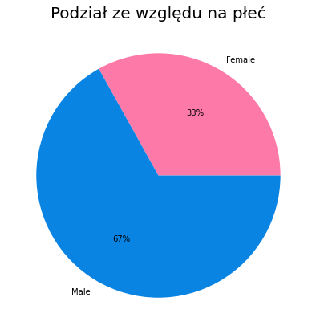

```python
plt.subplots(figsize=(7,7))
df_income.groupby(['gender']).size().plot(kind='pie', ylabel="", autopct='%1.0f%%', colors=['#fd79a8', '#0984e3'])
plt.title('Podział ze względu na płeć', fontsize=20)
df_income.groupby(['gender']).size()
```

```
Średnia liczba godzin przepracowanych w tygodniu dla całego zbioru: 40.41
```

```
gender
Female     2351
Male      10553
dtype: int64
```

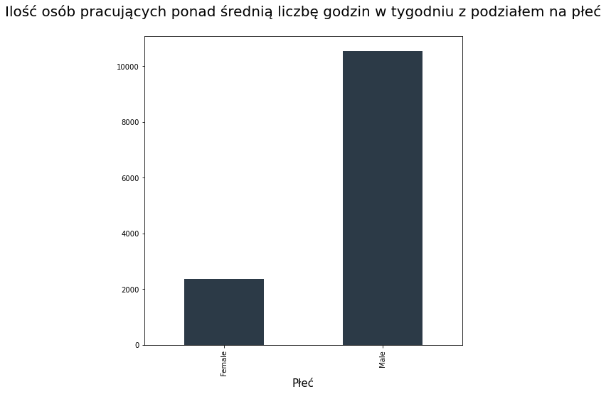

```python
plt.subplots(figsize=(8,8))
print("Średnia liczba godzin przepracowanych w tygodniu dla całego zbioru: ", end='')
print(np.round(df_income['hours-per-week'].mean(), 2))
df_income[(df_income['hours-per-week'] > df_income['hours-per-week'].mean())].groupby('gender').size().plot(kind='bar',
    ylabel="",
    color=['#2C3A47'],
)

plt.xlabel('Płeć', fontsize=15)
plt.title('Ilość osób pracujących ponad średnią liczbę godzin w tygodniu z podziałem na płeć\n', fontsize=20)
df_income[(df_income['hours-per-week'] > df_income['hours-per-week'].mean())].groupby('gender').size()
```

### Wykres kołowy przedstawiający podział całego zbioru danych ze względu na rasę

```
race
Amer-Indian-Eskimo      421
Asian-Pac-Islander     1373
Black                  4218
Other                   373
White                 37572
dtype: int64
```

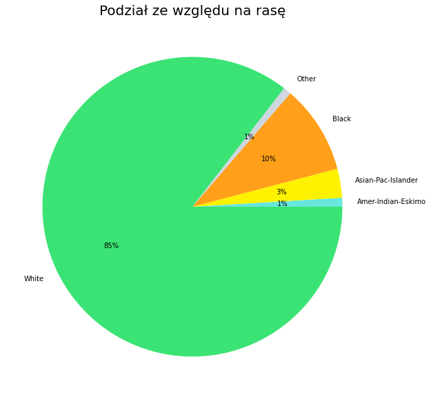

```python
plt.subplots(figsize=(10,10))
df_income.groupby(['race']).size().plot(kind='pie',ylabel="", autopct='%1.0f%%', colors=['#67e6dc', '#fff200', '#ff9f1a', '#ced6e0', '#3ae374' ])
plt.title('Podział ze względu na rasę', fontsize=20)
df_income.groupby(['race']).size()
```

### Wykres słupkowy przedstawiający podział całego zbioru ze względu na wiek

**Rozróżniliśmy 5 grup wiekowych:**

- 17 do 25 lat
- 26 do 35 lat
- 36 do 50 lat
- 51 do 68 lat
- oraz 68 i więcej

```python
numbers = []
age_ranges =["17-25 lat","26-35 lat","36-50 lat","51-68 lat","68+ lat"]
numbers.append(len(df_income[(df_income['age']>16) & (df_income['age']<=25)]))
numbers.append(len(df_income[(df_income['age']>25) & (df_income['age']<=35)]))
numbers.append(len(df_income[(df_income['age']>35) & (df_income['age']<=50)]))
numbers.append(len(df_income[(df_income['age']>50) & (df_income['age']<=68)]))
numbers.append(len(df_income[(df_income['age']>68)]))
```

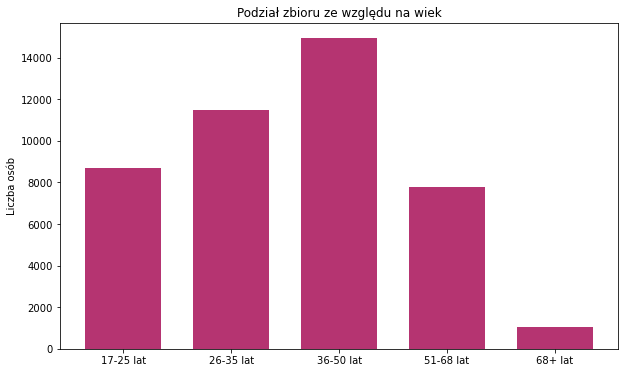

```python
plt.subplots(figsize=(10,6))
plt.bar(range(len(numbers)), numbers, width = 0.7, color='#B53471')
plt.title('Podział zbioru ze względu na wiek')
plt.ylabel('Liczba osób')
plt.xticks(np.arange(5), age_ranges)
plt.show()
```

## Analiza czasu pracy a zarobków

### Na tym wykresie przedstawiony mamy procentowy udział osób pracujących w poszczególnych zakresach godzinowych w tygodniu

**Na wykresie mamy wyraźnie przedstawione,że to właśnie osoby pracujące ponad 1 etat mają nawiększą szanse zarobić ponad $50k**

```python
df_income['income_>50K']>0

numbers = []
age_ranges =["0-20 h/week","21-40 h/week","40-60 h/week","61+/week"]
hours = [0,20,40,60]
for i in range(0,len(hours),1):
    if len(hours) == i+1:
        mianownik = len(df_income[df_income['hours-per-week']>hours[i]])
        licznik = len(df_income[(df_income['hours-per-week']>hours[i]) & (df_income['income_>50K']>0)])
        result = licznik/mianownik
    else:
        mianownik = len(df_income[(df_income['hours-per-week']>hours[i]) & (df_income['hours-per-week']<=hours[i+1])])
        licznik = len(df_income[(df_income['hours-per-week']>hours[i]) & (df_income['hours-per-week']<=hours[i+1]) & (df_income['income_>50K']>0)])
        result = licznik/mianownik
    numbers.append(result)
```

[figure not shown]

```python
plt.subplots(figsize=(19,12))
plt.plot(range(len(numbers)), numbers, marker="o", color='g', linewidth=4)
plt.title('Procentowy podział osób najwięcej zarabiających według godzin pracy',fontsize=16)
plt.ylabel("Część wszsytkich osób", fontsize=18)
plt.xticks(np.arange(4), age_ranges, fontsize=16)
plt.show()
```

# ============================================================

# Analizy pozwalające ustalić profil osoby mającej statystycznie największe szanse na zarobek powyżej 50 000 USD.

### Macierz przedstawiająca korelacje kolumn między sobą

**Zbadajmy korelację kolumny Income>50k z pozostałymi, a by stwierdzić co ma największy wpływ na wysokie zarobki**

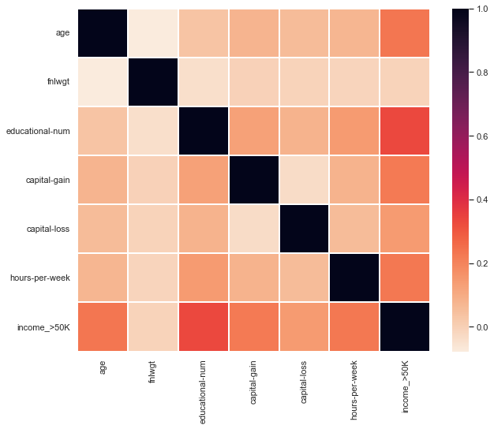

```python
m = df_income.corr()
sns.set(rc={"figure.figsize":(10, 8)}) #width=8, height=4
sns.heatmap(m,cmap="rocket_r", linewidths=0.1)
```

### Wykres kołowy przedstawiający ilość osób zarabiających więcej niż 50 000 USD rocznie

```
income_>50K
False    33439
True     10518
dtype: int64
```

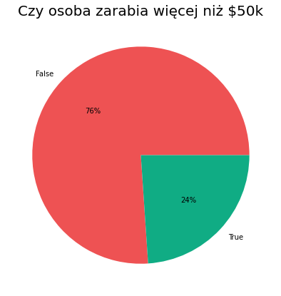

```python
plt.subplots(figsize=(7,7))
df_income.groupby(['income_>50K']).size().plot(kind='pie', ylabel='', autopct='%1.0f%%', colors=['#ee5253', '#10ac84'])
plt.title('Czy osoba zarabia więcej niż $50k', fontsize=20)
df_income.groupby(['income_>50K']).size()
```

```
                ========================================================================
```

## Liczymy w jakiej korelacji są zmienne `educational-num` oraz `income_>50K`. W praktyce sprawdzamy jak duży wpływ ma ilość lat nauki na osiągnięcie przez daną jednostkę zarobków powyżej 50 000 USD

```python
np.round(df_income["educational-num"].corr(df_income["income_>50K"]), 5)
```

```
0.33403
```

### Stosujemy funkcję unique() aby zobaczyć jakie wartości znajdują się w kolumnie `educational-num` w celu dobrania odpowiednich zakresów oraz łatwiejszego ich podzielenia

```python
list(df_income["educational-num"].unique())
```

```
[16, 8, 13, 4, 10, 9, 5, 6, 7, 14, 1, 3, 15, 11, 2, 12]
```

### Na podstawie powyższych danych przyjmujemy podział na 3 grupy:

- 0 do 4 lat
- 5 do 9 lat
- 10 do 15 lat

```python
educational_num_ages = []
educational_num_ranges = ["0-4 lata","5-9 lat","10-15 lat",]
educational_num_ages.append(
    len(df_income[(df_income['educational-num']>=0) & (df_income['educational-num']<=4) &
    (df_income['income_>50K'] == True)])
)

educational_num_ages.append(
    len(df_income[(df_income['educational-num']>=5) & (df_income['educational-num']<=9) &
    (df_income['income_>50K'] == True)])
)

educational_num_ages.append(
    len(df_income[(df_income['educational-num']>=10) & (df_income['educational-num']<=15) &
    (df_income['income_>50K'] == True)])
)

educational_num_ages
```

```
[91, 2471, 7572]
```

### Wykres przestawiający podział zbioru osób zarabiających powyżej 50k ze względu na liczbę lat nauki

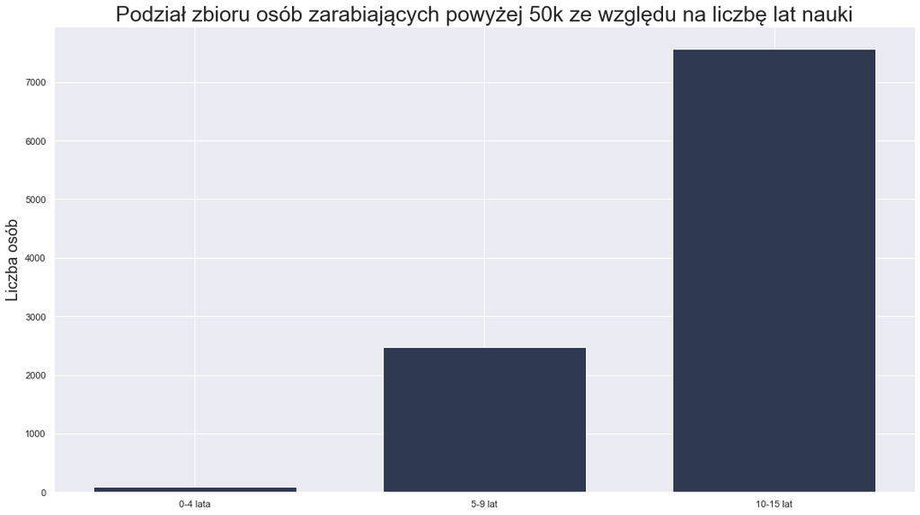

```python
plt.subplots(figsize=(18,10))
plt.bar(range(len(educational_num_ages)), educational_num_ages, width = 0.7, color='#303952')
plt.title('Podział zbioru osób zarabiających powyżej 50k ze względu na liczbę lat nauki', fontsize=25)
plt.ylabel('Liczba osób', fontsize=18)
plt.xticks(np.arange(len(educational_num_ranges)), educational_num_ranges)
plt.show()
```

```
                ========================================================================
```

## Liczymy w jakiej korelacji są zmienne `capital-gain` oraz `income_>50K`. W praktyce sprawdzamy jak duży wpływ ma wartość zdobytego kapitału na osiągnięcie przez daną jednostkę zarobków powyżej 50 000 USD

```python
np.round(df_income["capital-gain"].corr(df_income["income_>50K"]), 5)
```

```
0.22332
```

### Stosujemy funkcję np.arange() w celu automatycznego dobrania odpowiednich zakresów.

```python
capital_gain_ranges = np.arange(start=df_income["capital-gain"].min(), stop=df_income["capital-gain"].max(), step=20000)
capital_gain_ranges
```

```
array([    0, 20000, 40000, 60000, 80000])
```

### Na podstawie powyższych danych przyjmujemy podział na 5 grup:

- 0 do 20000 USD
- 20001 USD do 40000 USD
- 40001 USD do 60000 USD
- 60001 USD do 80000 USD
- 80001 i więcej

```python
capital_gain_amount = []
capital_gain_ranges_description = ["0 - 20000 USD","20001 - 40000 USD","40001 - 60000 USD", "60001 - 80000 USD", "80001 USD i więcej"]
capital_gain_amount.append(
    len(df_income[(df_income['capital-gain'] >= capital_gain_ranges[0]) & (df_income['educational-num']<=capital_gain_ranges[1]) &
    (df_income['income_>50K'] == True)])
)

capital_gain_amount.append(
    len(df_income[(df_income['capital-gain'] >= capital_gain_ranges[1] + 1) & (df_income['educational-num']<=capital_gain_ranges[2]) &
    (df_income['income_>50K'] == True)])
)

capital_gain_amount.append(
    len(df_income[(df_income['capital-gain'] >= capital_gain_ranges[2] + 1) & (df_income['educational-num']<=capital_gain_ranges[3]) &
    (df_income['income_>50K'] == True)])
)

capital_gain_amount.append(
    len(df_income[(df_income['capital-gain'] >= capital_gain_ranges[3] + 1) & (df_income['educational-num'] <= capital_gain_ranges[4]) &
    (df_income['income_>50K'] == True)])
)

capital_gain_amount.append(
    len(df_income[(df_income['capital-gain'] >= capital_gain_ranges[4] + 1) &
    (df_income['income_>50K'] == True)])
)

capital_gain_amount
```

```
[10518, 341, 228, 228, 228]
```

### Wykres przedstawiający podział zbioru osób zarabiających powyżej 50k ze względu na ilość osiągniętego kapitału w skali roku

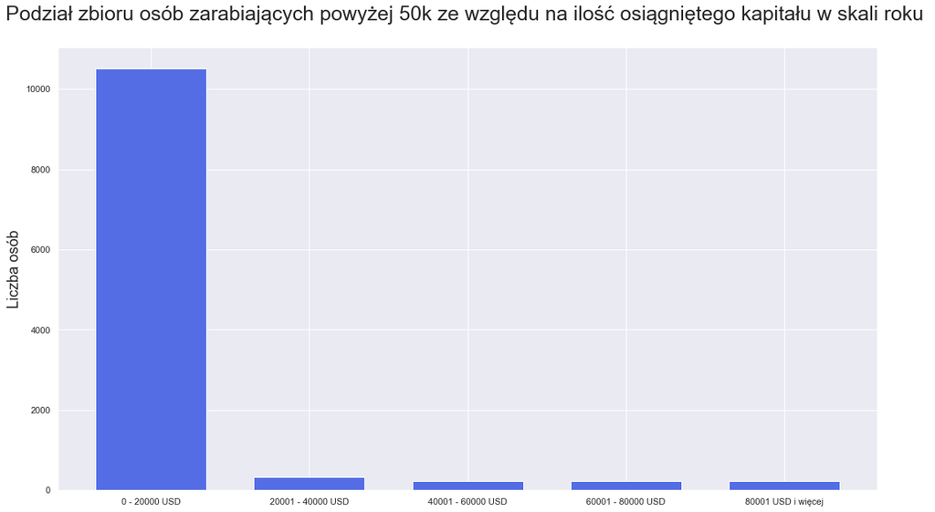

```python
plt.subplots(figsize=(18,10))
plt.bar(range(len(capital_gain_amount)), capital_gain_amount, width = 0.7, color='#546de5')
plt.title('Podział zbioru osób zarabiających powyżej 50k ze względu na ilość osiągniętego kapitału w skali roku \n', fontsize=25)
plt.ylabel('Liczba osób', fontsize=18)
plt.xticks(np.arange(len(capital_gain_ranges_description)), capital_gain_ranges_description)
plt.show()
```

```
                ========================================================================
```

## Liczymy w jakiej korelacji są zmienne `age` oraz `income_>50K`. W praktyce sprawdzamy jak duży wpływ ma wiek na osiągnięcie przez daną jednostkę zarobków powyżej 50 000 USD

```python
np.round(df_income["age"].corr(df_income["income_>50K"]), 5)
```

```
0.23099
```

### Wykres słupkowy przedstawiający podział osób z przychodem powyżej 50k ze względu na wiek

```python
numbers = []
age_ranges = ["17-26 lat","27-36 lat","37-46 lat","47-56 lat","57-66 lat","67+ lat"]
numbers.append(len(df_income[(df_income['age']>16) & (df_income['age']<=26) & (df_income['income_>50K'] == True)]))
numbers.append(len(df_income[(df_income['age']>26) & (df_income['age']<=36) & (df_income['income_>50K'] == True)]))
numbers.append(len(df_income[(df_income['age']>36) & (df_income['age']<=46) & (df_income['income_>50K'] == True)]))
numbers.append(len(df_income[(df_income['age']>46) & (df_income['age']<=56) & (df_income['income_>50K'] == True)]))
numbers.append(len(df_income[(df_income['age']>56) & (df_income['age']<=66) & (df_income['income_>50K'] == True)]))
numbers.append(len(df_income[(df_income['age']>67) & (df_income['income_>50K'] == True)]))
numbers
```

```
[225, 2428, 3738, 2723, 1130, 219]
```

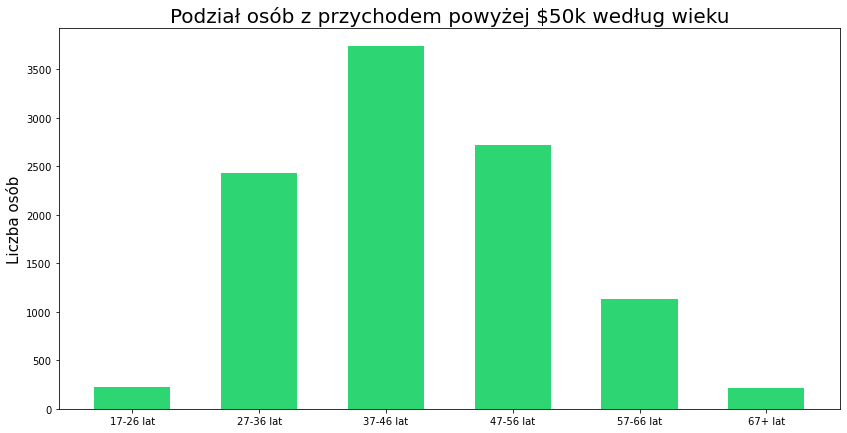

```python
plt.subplots(figsize=(14,7))
plt.bar(range(len(numbers)), numbers, width = 0.6, color='#2ed573')
plt.title('Podział osób z przychodem powyżej $50k według wieku', fontsize=20)
plt.ylabel('Liczba osób', fontsize=15)
plt.xticks(np.arange(len(age_ranges)), age_ranges)
plt.show()
```

```
                ========================================================================
```

## Liczymy w jakiej korelacji są zmienne `hours-per-week` oraz `income_>50K`. W praktyce sprawdzamy jak duży wpływ ma liczba przepracowanych w tygodniu godzin na osiągnięcie przez daną jednostkę zarobków powyżej 50 000 USD

```python
np.round(df_income["hours-per-week"].corr(df_income["income_>50K"]), 5)
```

```
0.22792
```

```python
hours_per_week_ranges = np.arange(start=df_income["hours-per-week"].min(), stop=df_income["hours-per-week"].max(), step=20)
hours_per_week_ranges
```

```
array([ 1, 21, 41, 61, 81])
```

### Na podstawie powyższych danych przyjmujemy podział na 5 grup:

- 1 do 20 godzin w tygodniu
- 21 do 40 godzin w tygodniu
- 41 do 60 godzin w tygodniu
- 61 do 80 godzin w tygodniu
- 81 i więcej godzin w tygodniu

```python
hours_per_week_amount = []
hours_per_week_range_description = ["1 - 20 h","21 - 40 h","41 - 60 h", "61 - 80 h", "81 h i więcej"]
hours_per_week_amount.append(
    len(df_income[(df_income['hours-per-week'] >= hours_per_week_ranges[0]) & (df_income['educational-num'] <= hours_per_week_ranges[1] - 1) &
    (df_income['income_>50K'] == True)])
)

hours_per_week_amount.append(
    len(df_income[(df_income['hours-per-week'] >= hours_per_week_ranges[1]) & (df_income['educational-num'] <= hours_per_week_ranges[2] - 1) &
    (df_income['income_>50K'] == True)])
)

hours_per_week_amount.append(
    len(df_income[(df_income['hours-per-week'] >= hours_per_week_ranges[2]) & (df_income['educational-num'] <= hours_per_week_ranges[3] - 1) &
    (df_income['income_>50K'] == True)])
)

hours_per_week_amount.append(
    len(df_income[(df_income['hours-per-week'] >= hours_per_week_ranges[3]) & (df_income['educational-num'] <= hours_per_week_ranges[4] -1 ) &
    (df_income['income_>50K'] == True)])
)

hours_per_week_amount.append(
    len(df_income[(df_income['hours-per-week'] >= hours_per_week_ranges[4]) &
    (df_income['income_>50K'] == True)])
)

hours_per_week_amount
```

```
[10518, 10249, 5173, 529, 95]
```

### Wykres przedstawiający podział osób z przychodem powyżej 50k według ilości przepracowanych godzin w ciągu tygodnia

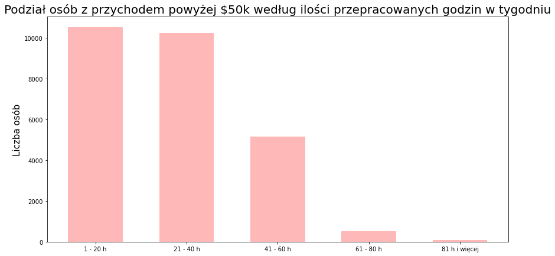

```python
plt.subplots(figsize=(14,7))
plt.bar(range(len(hours_per_week_amount)), hours_per_week_amount, width = 0.6, color='#ffb8b8')
plt.title('Podział osób z przychodem powyżej $50k według ilości przepracowanych godzin w tygodniu', fontsize=20)
plt.ylabel('Liczba osób', fontsize=15)
plt.xticks(np.arange(len(hours_per_week_range_description)), hours_per_week_range_description)
plt.show()
```

```
                ========================================================================
```

### Wykres kołowy dzielący zbiór osób zarabiających powyżej 50k ze względu na wykonywany zawód

```
occupation
Adm-clerical          668
Armed-Forces            4
Craft-repair         1259
Exec-managerial      2633
Farming-fishing       158
Handlers-cleaners     131
Machine-op-inspct     328
Other-service         182
Priv-house-serv         3
Prof-specialty       2496
Protective-serv       280
Sales                1337
Tech-support          383
Transport-moving      420
dtype: int64
```

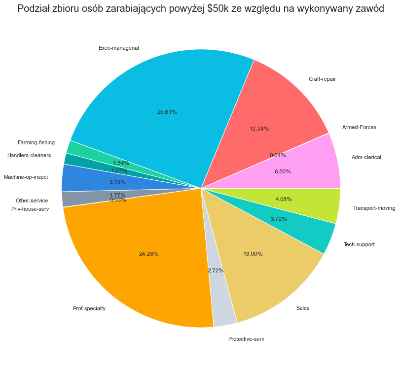

```python
plt.subplots(figsize=(13,13))
df_income[df_income["income_>50K"] == True].groupby(['occupation']).size().plot(
    kind='pie',
    ylabel='',
    autopct='%.2f%%',
    colors=['#ff9ff3','#feca57','#ff6b6b','#0abde3','#1dd1a1','#01a3a4','#2e86de','#8395a7','#222f3e', '#ffa502', '#ced6e0', '#eccc68', '#12CBC4', '#C4E538']
)
plt.title('Podział zbioru osób zarabiających powyżej $50k ze względu na wykonywany zawód', fontsize=20)
df_income[df_income["income_>50K"] == True].groupby(['occupation']).size()
```

```
                ========================================================================
```

### Wykres kołowy dzielący zbiór osób zarabiających powyżej 50k ze względu na formę zatrudnienia

```
workclass
Federal-gov          507
Local-gov            848
Private             6641
Self-emp-inc         853
Self-emp-not-inc     958
State-gov            473
Without-pay            2
dtype: int64
```

[figure not shown]

```python
plt.subplots(figsize=(13,13))
df_income[df_income["income_>50K"] == True].groupby(['workclass']).size().plot(
    kind='pie',
    ylabel='',
    autopct= '%.2f%%',
    colors=['#ff9ff3','#feca57','#ff6b6b','#0abde3','#1dd1a1','#01a3a4','#2e86de','#8395a7','#ffb8b8', '#ffa502', '#ced6e0', '#eccc68', '#12CBC4', '#C4E538'],
)
plt.title('Podział zbioru osób zarabiających powyżej $50k ze względu na sektor zatrudnienia', fontsize=20)
df_income[df_income["income_>50K"] == True].groupby(['workclass']).size()
```

```
                ========================================================================
```

### Wykres kołowy dzielący zbiór osób zarabiających powyżej 50k ze względu na posiadane wykształcenie

```
education
10th              82
11th              84
12th              44
1st-4th            7
5th-6th           26
7th-8th           57
9th               37
Assoc-acdm       385
Assoc-voc        469
Bachelors       2989
Doctorate        384
HS-grad         2224
Masters         1328
Preschool          1
Prof-school      551
Some-college    1850
dtype: int64
```

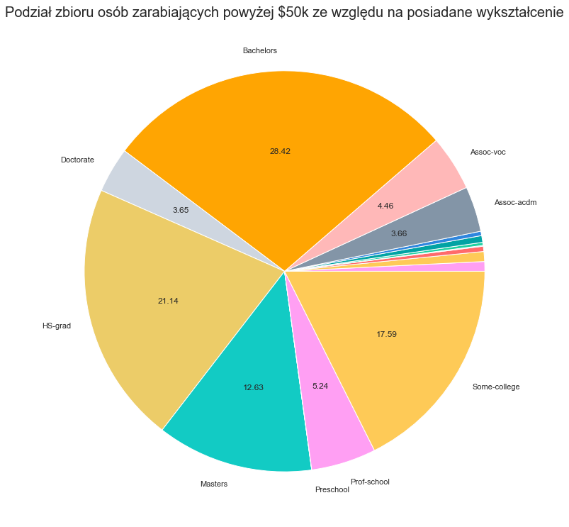

```python
#Funkcje pozwalające na poprawę czytelności wykresu:
def autopct(pct):
    return ('%.2f' % pct) if pct > 1 else ''

def is_contains(x):
    if 'th' in x:
        return None
    else:
        return x

labels = df_income[df_income["income_>50K"] == True].groupby(['education']).size().keys().map(lambda x: is_contains(x))
#================================

plt.subplots(figsize=(13,13))
df_income[df_income["income_>50K"] == True].groupby(['education']).size().plot(
    kind='pie',
    ylabel='',
    autopct= lambda x: autopct(x),
    labels=labels,
    colors=['#ff9ff3','#feca57','#ff6b6b','#0abde3','#1dd1a1','#01a3a4','#2e86de','#8395a7','#ffb8b8', '#ffa502', '#ced6e0', '#eccc68', '#12CBC4', '#C4E538'],
)
plt.title('Podział zbioru osób zarabiających powyżej $50k ze względu na posiadane wykształcenie', fontsize=20)
df_income[df_income["income_>50K"] == True].groupby(['education']).size()
```

```
                ========================================================================
```

### Wykres kołowy dzielący zbiór osób zarabiających powyżej 50k ze względu na stan cywilny

```
marital-status
Divorced                  602
Married-AF-spouse          11
Married-civ-spouse       8985
Married-spouse-absent      54
Never-married             669
Separated                  84
Widowed                   113
dtype: int64
```

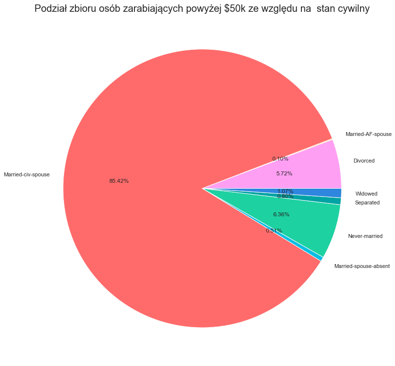

```python
plt.subplots(figsize=(13,13))
df_income[df_income["income_>50K"] == True].groupby(['marital-status']).size().plot(
    kind='pie',
    ylabel='',
    autopct= '%.2f%%',
    colors=['#ff9ff3','#feca57','#ff6b6b','#0abde3','#1dd1a1','#01a3a4','#2e86de','#8395a7','#ffb8b8', '#ffa502', '#ced6e0', '#eccc68', '#12CBC4', '#C4E538'],
)
plt.title('Podział zbioru osób zarabiających powyżej $50k ze względu na  stan cywilny', fontsize=20)
df_income[df_income["income_>50K"] == True].groupby(['marital-status']).size()
```

```
                ========================================================================
```

### Wykres kołowy dzielący zbiór osób zarabiających powyżej 50k ze względu na rolę w związku

```
relationship
Husband           7965
Not-in-family     1150
Other-relative      46
Own-child          102
Unmarried          277
Wife               978
dtype: int64
```

[figure not shown]

```python
plt.subplots(figsize=(13,13))
df_income[df_income["income_>50K"] == True].groupby(['relationship']).size().plot(
    kind='pie',
    ylabel='',
    autopct= '%.2f%%',
    colors=['#3867d6','#feca57','#ff6b6b','#0abde3','#1dd1a1','#01a3a4','#2e86de','#8395a7','#ffb8b8', '#ffa502', '#ced6e0', '#eccc68', '#12CBC4', '#C4E538'],
)
plt.title('Podział zbioru osób zarabiających powyżej $50k ze względu na rolę w związku', fontsize=20)
df_income[df_income["income_>50K"] == True].groupby(['relationship']).size()
```

```
                ========================================================================
```

### Wykres kołowy dzielący zbiór osób zarabiających powyżej 50k ze względu na rasę

```
race
Amer-Indian-Eskimo      48
Asian-Pac-Islander     367
Black                  524
Other                   44
White                 9535
dtype: int64
```

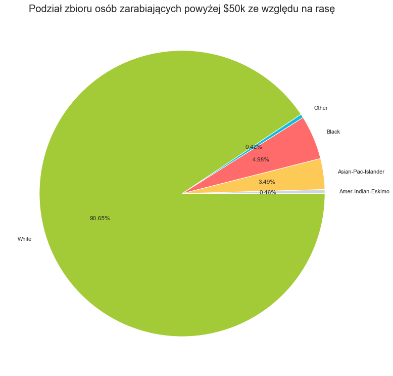

```python
plt.subplots(figsize=(13,13))
df_income[df_income["income_>50K"] == True].groupby(['race']).size().plot(
    kind='pie',
    ylabel='',
    autopct= '%.2f%%',
    colors=['#ced6e0','#feca57','#ff6b6b','#0abde3','#A3CB38','#01a3a4','#2e86de','#8395a7','#ffb8b8', '#ffa502', '#ced6e0', '#eccc68', '#12CBC4', '#C4E538'],
)
plt.title('Podział zbioru osób zarabiających powyżej $50k ze względu na rasę', fontsize=20)
df_income[df_income["income_>50K"] == True].groupby(['race']).size()
```

```
                ========================================================================
```

### Wykres kołowy dzielący zbiór osób zarabiających powyżej 50k ze względu na płeć

```
gender
Female    1590
Male      8928
dtype: int64
```

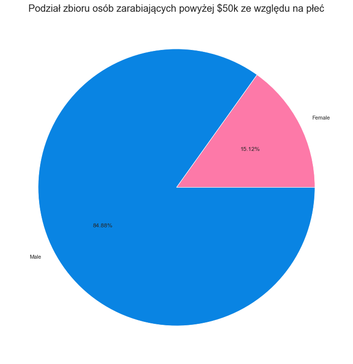

```python
plt.subplots(figsize=(13,13))
df_income[df_income["income_>50K"] == True].groupby(['gender']).size().plot(
    kind='pie',
    ylabel='',
    autopct= '%.2f%%',
    colors=['#fd79a8', '#0984e3'],
)
plt.title('Podział zbioru osób zarabiających powyżej $50k ze względu na płeć', fontsize=20)
df_income[df_income["income_>50K"] == True].groupby(['gender']).size()
```

```
                ========================================================================
```

# Podsumowanie oraz wnioski:

#### Ogólne podsumowanie:

Przeanalizowaliśmy wykresy pod kątem cech jakie powinna mieć osoba, aby miała jak największe szanse na zarabianie przynajmniej 50 000$ rocznie. Ten próg został przez nas wybrany, ponieważ według nas gwarantuje życie na stabilnym poziomie. Na początku zaprezentowaliśmy co dokładnie zawiera zestaw danych oraz przykładowe rekordy danych. Następnie przedstawiliśmy podstawowe statystki, w których zaprezentowaliśmy takie dane jak:

- Minimalny wiek w zbiorze
- Maksymalny wiek w zbiorze
- Średni wiek w zbiorze
- 5 najczęściej wykonywanych zawodów
- Rekord posiadający największy zysk kapitałowy
- Rekord posiadający największą stratę zysku kapitałowego
- Osoba pracująca najwięcej tygodniowo
- Osoba pracująca najmniej tygodniowo

  #### Następnie utworzyliśmy podstawowe wykresy danych i odpowiednio je zinterpretowaliśmy:
- Podzieliliśmy cały zbiór na płeć i otrzymaliśmy, że w zbiorze jest około dwa razy więcej mężczyzn niż kobiet
- Pokazaliśmy, że osoby w datasecie pracują średnio 40 godzin tygodniowo, a pracujących ponad 40 godzin tygodniowo mężczyzn jest około 5 razy więcej niż kobiet
- Podzieliliśmy zbiór według rasy i przeważającą grupą osób były osoby rasy białej.
- Dominującą grupą wiekową w naszej bazie była grupa 36-50 lat

  #### Kolejnym etapem było wyznaczenie profilu osoby zarabiającej przynajmniej 50 tysięcy dolarów rocznie:

W tym celu, w pierwszej kolejności utworzyliśmy macierz korelacji, aby sprawdzić, które kolumny są najlepiej skorelowane z kolumną `income_50k`. Kolumną najlepiej skorelowaną okazała się być kolumna `educational-num`. Kolejną wstępną statystyką którą przeprowadziliśmy było pokazanie podziału datasetu na osoby zarabiające ponad i poniżej $50k, aby zwizualizować tę różnicę, pokazaliśmy ją na wykresie kołowy Z kolejnych wykresów staraliśmy się już wyznaczyć bezpośrednio profil osoby dobrze zarabiającej: **Taka osoba według danych zebranych w naszej bazie powinna:**

  Z policzonej przez nas korelacji wynika również że czynnikiem najbardziej wpływającym na osiągnięcie przez daną jednoste przychodów powyżej wyznaczonego przez nas progu zarobków **jest edukacja, oraz lata nauki**, czego można się było spodziewać. Pozostałe zmienne takie jak płeć, rasa, czy relacje danej jednostki mają mniejszy wpływ na przedstawianą przez nas statystykę.